# TDF Velogames Daily Update

### Race Results - Stage 20

Here’s the non-spoiler 4min highlight clip on Youtube:  
https://www.youtube.com/watch?v=3Ze0us3L9co  
Polish rider Maciej Bodnar collected the biggest win of his career by winning the Stage 20 Individual Time Trial in Marseille last night. Chris Froome finished strongly only six seconds behind Bodnar to secure his yellow jersey and with it his grip on a fourth Tour De France success. Bardet did not do as well, losing significant time and allowing Uran to jump over him into second. Bardet holds third over Landa by only one second. Michel Kwiatkowski finishied second on the stage, only one second behind fellow Pole Bodnar. Amazing given how much work we’ve seen Kwiatkowski perform on behalf of his SKY team leader at the front of the peloton over the last three weeks.  
The mostly flat 22.5km course was market by a nasty climb with grades of up to 16%. Many of the riders looked pretty awkward climbing this sharp ascent on their TT machines!  
Results on cycling news:  
http://www.cyclingnews.com/tour-de-france/stage-20/results/

| Stage Result |
| --- |

|  | # | Rider Name (Country) Team | Result |
| --- | --- | --- | --- |
| 2 | 1 | Maciej Bodnar (Pol) Bora-Hansgrohe | 0:28:15 |
| 3 | 2 | Michal Kwiatkowski (Pol) Team Sky | 0:00:01 |
| 4 | 3 | Christopher Froome (GBr) Team Sky | 0:00:06 |
| 5 | 4 | Tony Martin (Ger) Katusha-Alpecin | 0:00:14 |
| 6 | 5 | Daryl Impey (RSA) Orica-Scott | 0:00:20 |
| 7 | 6 | Alberto Contador (Spa) Trek-Segafredo | 0:00:21 |
| 8 | 7 | Nikias Arndt (Ger) Team Sunweb | 0:00:28 |
| 9 | 8 | Rigoberto Uran (Col) Cannondale-Drapac | 0:00:31 |
| 10 | 9 | Stefan Küng (Swi) BMC Racing Team | 0:00:34 |
| 11 | 10 | Sylvain Chavanel (Fra) Direct Energie | 0:00:37 |

| General classification after stage 20 |
| --- |

|  | # | Rider Name (Country) Team | Result |
| --- | --- | --- | --- |
| 2 | 1 | Christopher Froome (GBr) Team Sky | 83:55:16 |
| 3 | 2 | Rigoberto Uran (Col) Cannondale-Drapac | 0:00:54 |
| 4 | 3 | Romain Bardet (Fra) AG2R La Mondiale | 0:02:20 |
| 5 | 4 | Mikel Landa (Spa) Team Sky | 0:02:21 |
| 6 | 5 | Fabio Aru (Ita) Astana Pro Team | 0:03:05 |
| 7 | 6 | Daniel Martin (Irl) Quick-Step Floors | 0:04:42 |
| 8 | 7 | Simon Yates (GBr) Orica-Scott | 0:06:14 |
| 9 | 8 | Louis Meintjes (RSA) UAE Team Emirates | 0:08:20 |
| 10 | 9 | Alberto Contador (Spa) Trek-Segafredo | 0:08:49 |
| 11 | 10 | Warren Barguil (Fra) Team Sunweb | 0:09:25 |

| Points |
| --- |

|  | # | Rider Name (Country) Team | Result |
| --- | --- | --- | --- |
| 2 | 1 | Maciej Bodnar (Pol) Bora-Hansgrohe | 20 |
| 3 | 2 | Michal Kwiatkowski (Pol) Team Sky | 17 |
| 4 | 3 | Christopher Froome (GBr) Team Sky | 15 |
| 5 | 4 | Tony Martin (Ger) Katusha-Alpecin | 13 |
| 6 | 5 | Daryl Impey (RSA) Orica-Scott | 11 |
| 7 | 6 | Alberto Contador (Spa) Trek-Segafredo | 10 |
| 8 | 7 | Nikias Arndt (Ger) Team Sunweb | 9 |
| 9 | 8 | Rigoberto Uran (Col) Cannondale-Drapac | 8 |
| 10 | 9 | Stefan Küng (Swi) BMC Racing Team | 7 |
| 11 | 10 | Sylvain Chavanel (Fra) Direct Energie | 6 |

| Points classification |
| --- |

|  | # | Rider Name (Country) Team | Result |
| --- | --- | --- | --- |
| 2 | 1 | Michael Matthews (Aus) Team Sunweb | 364 |
| 3 | 2 | André Greipel (Ger) Lotto Soudal | 204 |
| 4 | 3 | Edvald Boasson Hagen (Nor) Dimension Data | 200 |
| 5 | 4 | Sonny Colbrelli (Ita) Bahrain-Merida | 163 |
| 6 | 5 | Alexander Kristoff (Nor) Katusha-Alpecin | 158 |
| 7 | 6 | Thomas De Gendt (Bel) Lotto Soudal | 146 |
| 8 | 7 | Christopher Froome (GBr) Team Sky | 133 |
| 9 | 8 | Rigoberto Uran (Col) Cannondale-Drapac | 106 |
| 10 | 9 | Daniel Martin (Irl) Quick-Step Floors | 106 |
| 11 | 10 | Warren Barguil (Fra) Team Sunweb | 100 |

### Velogames Results - 4051 Rouleurs - Stage 20

#### Highest Scoring Riders

##### for the stage, from our teams

The riders earning maximum points for Stage 20, and the teams that picked them were:

| rider | stage | Total | Selected by |
| --- | --- | --- | --- |
| Michal Kwiatkowski | 20 | 150 | Lanterne Rouge |
| Christopher Froome | 20 | 147 | Wilston Wippets,Dick`s Dodgers,The Ron Burgandy All Stars,Ferris Wheel,TDF 101,Top Nobs |
| Tony Martin | 20 | 100 | Gears n Beers,Champagne Taste,Saddle Sores,Brake Rub Regression,Oldies,2 seconds faster |
| Rigoberto Uran | 20 | 72 | Saddle Sores,The Paranoid Androids ,Maluka |
| Sylvain Chavanel | 20 | 30 | The Ron Burgandy All Stars,The Smiling Assassins,Gruppetto Greats ,Bianchi |

Another take on rider data is provided in the chart below displaying Rider Cost vs the their Total Points accrued so far. The size of each circle is proportional the the number of teams that have selected that rider.

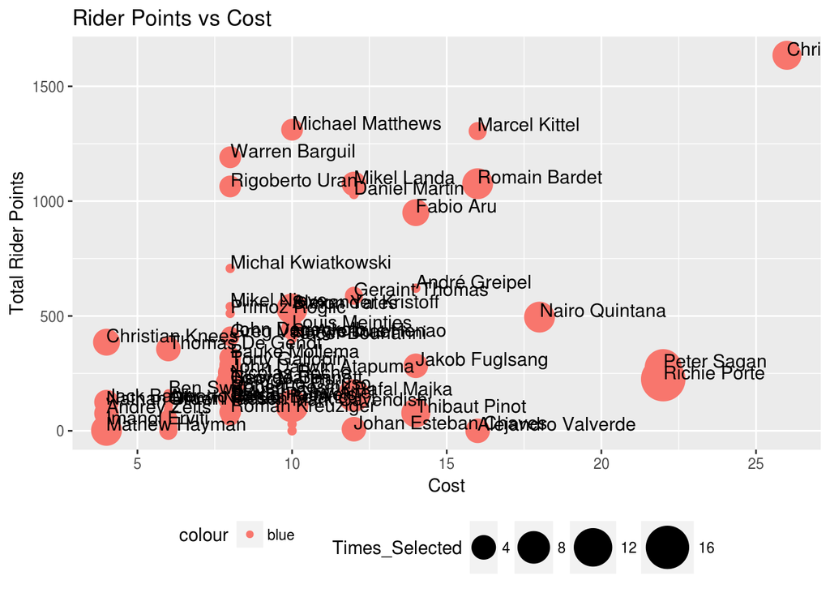

#### Top scoring teams for stage

So Rich Johnston cleaned up stage 20.

| team | directeur | Stage_Points |
| --- | --- | --- |
| Dick`s Dodgers | Rich Johnston | 217 |
| Wilston Wippets | Peter Howes | 212 |
| Saddle Sores | Brett Jensen | 202 |
| The Ron Burgandy All Stars | Steve Kelsall | 198 |
| Lanterne Rouge | Andrew Carroll | 192 |
| Ferris Wheel | Jeff Beehler | 180 |
| Top Nobs | Chris Forini | 170 |
| Brake Rub Regression | Simon Lyons | 161 |
| TDF 101 | Luke Jardine | 156 |
| 2 seconds faster | Dean McBeath | 146 |
| Oldies | Jim Martin | 138 |
| Champagne Taste | Britt Groom | 133 |
| Gears n Beers | Chris Fraser | 118 |
| The Paranoid Androids | Mick Groom | 97 |
| Little Crookies | Crooky | 79 |
| Maluka | MurrayMaluka | 77 |
| Gruppetto Greats | David Pink | 75 |
| gagnants | mark fitzpatrick | 62 |
| Bianchi | Jamie Forster | 60 |
| The Smiling Assassins | Andrew Glutz | 39 |
| Chamois Shakers | Matt | 31 |
| Legless | David Leggett | 21 |
| Thistles | Simon Scott | 19 |
| Itchy Nads | Dan | 17 |
| Opto`s TDF Weapons | Mark Hinds | 12 |

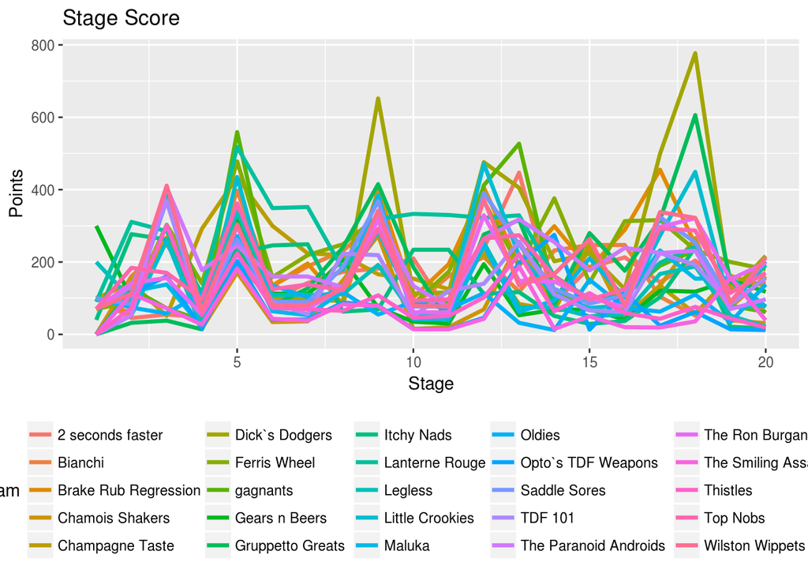

The picture for overall after 20 stages is:

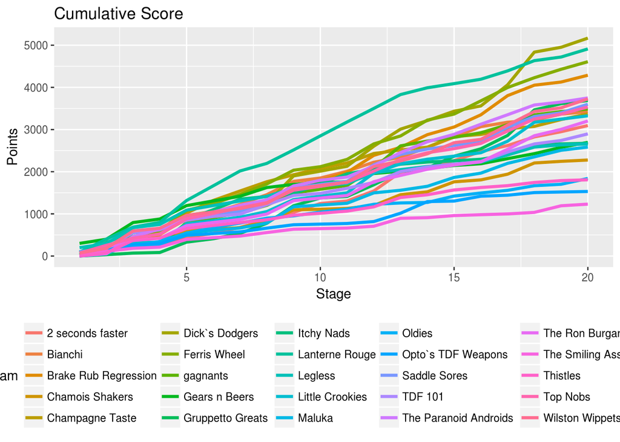

| Team | Total |
| --- | --- |
| Dick`s Dodgers | 5168 |
| Lanterne Rouge | 4912 |
| Ferris Wheel | 4609 |
| Brake Rub Regression | 4288 |
| The Paranoid Androids | 3749 |
| Wilston Wippets | 3727 |
| Gruppetto Greats | 3688 |
| Saddle Sores | 3600 |
| Top Nobs | 3536 |
| gagnants | 3488 |
| Bianchi | 3426 |
| Champagne Taste | 3370 |
| Little Crookies | 3326 |
| The Ron Burgandy All Stars | 3203 |
| 2 seconds faster | 3095 |
| TDF 101 | 2897 |
| Gears n Beers | 2696 |
| Itchy Nads | 2676 |
| Legless | 2657 |
| Maluka | 2585 |
| Chamois Shakers | 2277 |
| Oldies | 1840 |
| Thistles | 1808 |
| Opto`s TDF Weapons | 1531 |
| The Smiling Assassins | 1231 |

#### Inside Look

Next up is Stage 21.  
http://www.cyclingnews.com/tour-de-france/stage-21/

### Team Cross Reference

Here’s the team breakdown for each of squads.

| rider | Times_Selected | Andrew Carroll | Andrew Glutz | Brett Jensen | Britt Groom | Chris Forini | Chris Fraser | Crooky | Dan | David Leggett | David Pink | Dean McBeath | Jamie Forster | Jeff Beehler | Jim Martin | Luke Jardine | mark fitzpatrick | Mark Hinds | Matt | Mick Groom | MurrayMaluka | Peter Howes | Rich Johnston | Simon Lyons | Simon Scott | Steve Kelsall |
| --- | --- | --- | --- | --- | --- | --- | --- | --- | --- | --- | --- | --- | --- | --- | --- | --- | --- | --- | --- | --- | --- | --- | --- | --- | --- | --- |
| Richie Porte | 17 | Yes | Yes | Yes | Yes | Yes | Yes |  | Yes | Yes | Yes |  | Yes |  | Yes |  | Yes | Yes | Yes |  | Yes |  |  | Yes | Yes |  |
| Peter Sagan | 11 |  |  | Yes |  |  | Yes | Yes | Yes | Yes |  |  |  |  |  | Yes |  |  | Yes | Yes |  | Yes | Yes |  | Yes |  |
| Mark Cavendish | 8 |  | Yes |  |  | Yes |  |  |  |  |  |  | Yes |  |  |  | Yes | Yes | Yes |  | Yes |  |  |  |  | Yes |
| Rafal Majka | 8 |  |  |  | Yes |  | Yes |  |  |  |  |  |  | Yes | Yes |  |  |  |  | Yes | Yes | Yes |  |  |  | Yes |
| Mathew Hayman | 7 | Yes | Yes |  |  |  |  | Yes |  | Yes |  |  |  |  |  | Yes |  |  |  | Yes |  |  |  |  |  | Yes |
| Nairo Quintana | 7 |  | Yes |  |  |  |  |  |  |  |  | Yes |  |  |  | Yes | Yes | Yes |  | Yes |  |  |  |  | Yes |  |
| Romain Bardet | 7 |  |  |  |  |  |  | Yes |  | Yes | Yes |  |  |  |  |  |  |  |  |  |  | Yes | Yes | Yes |  | Yes |
| Simon Yates | 7 | Yes |  |  |  |  |  | Yes | Yes |  |  | Yes |  |  |  |  | Yes |  |  | Yes |  |  |  | Yes |  |  |
| Christopher Froome | 6 |  |  |  |  | Yes |  |  |  |  |  |  |  | Yes |  | Yes |  |  |  |  |  | Yes | Yes |  |  | Yes |
| Thibaut Pinot | 6 |  | Yes |  |  |  |  |  |  |  | Yes | Yes |  |  |  |  |  |  |  |  | Yes |  |  |  | Yes | Yes |
| Tony Martin | 6 |  |  | Yes | Yes |  | Yes |  |  |  |  | Yes |  |  | Yes |  |  |  |  |  |  |  |  | Yes |  |  |
| Christian Knees | 5 | Yes |  |  |  |  | Yes |  |  | Yes |  |  |  |  |  |  |  |  |  |  |  |  | Yes |  | Yes |  |
| Fabio Aru | 5 |  |  |  | Yes |  |  | Yes |  |  |  |  | Yes | Yes |  |  | Yes |  |  |  |  |  |  |  |  |  |
| Alejandro Valverde | 4 |  |  |  |  |  |  | Yes |  |  |  |  |  | Yes | Yes |  |  | Yes |  |  |  |  |  |  |  |  |
| Andrey Zeits | 4 |  |  |  |  |  |  |  |  | Yes |  |  |  |  |  |  | Yes |  |  |  |  |  |  | Yes | Yes |  |
| Jack Bauer | 4 |  |  |  |  |  |  | Yes |  |  |  |  |  |  | Yes |  |  |  |  |  |  | Yes | Yes |  |  |  |
| Jakob Fuglsang | 4 | Yes |  |  |  |  |  |  |  |  |  |  | Yes |  |  |  |  |  |  |  | Yes |  |  | Yes |  |  |
| Johan Esteban Chaves | 4 |  | Yes |  |  |  |  |  |  | Yes |  | Yes |  |  |  |  |  |  | Yes |  |  |  |  |  |  |  |
| John Darwin Atapuma | 4 |  |  |  |  |  |  | Yes | Yes |  | Yes |  |  |  |  |  |  |  |  |  |  |  | Yes |  |  |  |
| Mikel Landa | 4 |  |  | Yes |  | Yes |  |  |  |  |  | Yes |  |  |  |  | Yes |  |  |  |  |  |  |  |  |  |
| Sylvain Chavanel | 4 |  | Yes |  |  |  |  |  |  |  | Yes |  | Yes |  |  |  |  |  |  |  |  |  |  |  |  | Yes |
| Thomas De Gendt | 4 |  |  |  | Yes |  | Yes |  |  |  |  |  |  | Yes |  |  |  |  |  |  | Yes |  |  |  |  |  |
| Bauke Mollema | 3 |  |  |  | Yes |  |  |  |  |  |  |  | Yes |  |  |  |  |  |  |  |  | Yes |  |  |  |  |
| Imanol Erviti | 3 |  |  |  |  |  |  |  | Yes |  |  |  |  |  |  |  | Yes |  |  |  |  |  |  |  | Yes |  |
| Louis Meintjes | 3 | Yes |  |  |  |  | Yes |  |  |  |  |  |  |  | Yes |  |  |  |  |  |  |  |  |  |  |  |
| Michael Matthews | 3 |  |  |  |  |  |  |  |  |  |  |  | Yes | Yes |  |  |  |  |  |  |  |  |  | Yes |  |  |
| Nicolas Roche | 3 |  |  |  |  |  |  |  |  |  | Yes | Yes |  |  |  |  |  |  | Yes |  |  |  |  |  |  |  |
| Rigoberto Uran | 3 |  |  | Yes |  |  |  |  |  |  |  |  |  |  |  |  |  |  |  | Yes | Yes |  |  |  |  |  |
| Roman Kreuziger | 3 |  |  | Yes |  |  |  |  |  |  | Yes |  | Yes |  |  |  |  |  |  |  |  |  |  |  |  |  |
| Tony Gallopin | 3 |  |  |  |  |  |  |  |  |  |  |  |  |  | Yes |  |  |  |  | Yes | Yes |  |  |  |  |  |

[output cut: 52 more lines]

| Name | Nationality | Team | Pos. |
| --- | --- | --- | --- |
| Geraint Thomas | Great Britain | Team Sky | DNF-9 |
| Alejandro Valverde | Spain | Movistar Team | DNF-1 |
| Fabio Felline | Italy | Trek–Segafredo | DNF-14 |
| Richie Porte | Australia | BMC Racing Team | DNF-9 |
| Dario Cataldo | Italy | Astana | DNF-11 |
| Jakob Fuglsang | Denmark | Astana | DNF-13 |
| Manuele Mori | Italy | UAE Team Emirates | DNF-9 |
| Arnaud Démare | France | FDJ | HD-9 |
| Mickaël Delage | France | FDJ | HD-9 |
| Jacopo Guarnieri | Italy | FDJ | HD-9 |
| Ignatas Konovalovas | Lithuania | FDJ | HD-9 |
| Thibaut Pinot | France | FDJ | DNF-17 |
| Arthur Vichot | France | FDJ | DNF-13 |
| Luke Durbridge | Australia | Orica–Scott | DNF-2 |
| Mark Cavendish | Great Britain | Team Dimension Data | DNS-5 |
| Mark Renshaw | Australia | Team Dimension Data | HD-9 |
| Marcel Kittel | Germany | Quick-Step Floors | DNF-17 |
| Philippe Gilbert | Belgium | Quick-Step Floors | DNS-16 |
| Matteo Trentin | Italy | Quick-Step Floors | HD-9 |
| Peter Sagan | Slovakia | Bora–Hansgrohe | DSQ-4 |
| Rafał Majka | Poland | Bora–Hansgrohe | DNS-10 |
| Juraj Sagan | Slovakia | Bora–Hansgrohe | HD-9 |
| Marcel Sieberg | Germany | Lotto–Soudal | DNS-17 |
| Tim Wellens | Belgium | Lotto–Soudal | DNF-15 |
| Robert Gesink | Netherlands | LottoNL–Jumbo | DNF-9 |
| George Bennett | New Zealand | LottoNL–Jumbo | DNF-16 |
| Timo Roosen | Netherlands | LottoNL–Jumbo | DNF-19 |
| Jos van Emden | Netherlands | LottoNL–Jumbo | DNF-9 |
| Ion Izagirre | Spain | Bahrain–Merida | DNF-1 |
| Ondřej Cink | Czech Republic | Bahrain–Merida | DNF-19 |
| Daniel McLay | Great Britain | Fortuneo–Oscaro | DNF-17 |